# Lesson 23 - Variance Inflation Factors

Robbie Beane

# Load Packages

```r
require(car)
require(MASS)
require(openintro)
```

# Multicolinearity

When we have only two predictors, we can detect the presence of collinearity fairly reliably by using a pairs plot or a correlation matrix. Detecting multicollinearity in a larger set of predictors is not so easy, however.

Assume that we have 5 predictors, $X1, ..., X5$ that satisfy the following properties:

- For any $i,j < 5$ such that $i \neq j$, we have that $\mathrm{corr}(X_i,X_j) = 0$.
- $X5$ is very nearly an average of the other four predictors.

Let’s consider a pairs plot of our predictors.

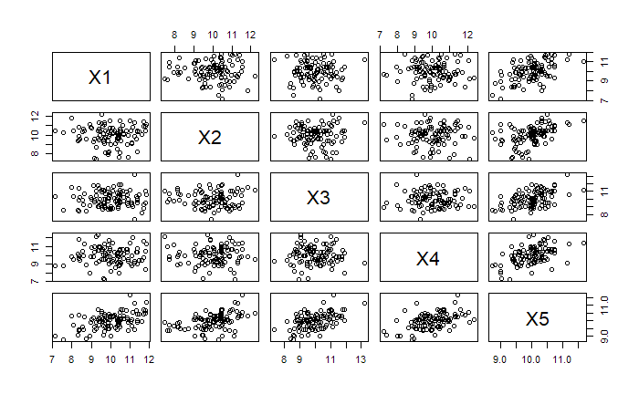

```r
pairs(df)
```

Let’s now look at a correlation matrix for our predictors.

```r
round(cor(df), 2)
```

```
     X1   X2  X3   X4   X5
X1 1.00 0.00 0.0 0.00 0.51
X2 0.00 1.00 0.0 0.00 0.46
X3 0.00 0.00 1.0 0.00 0.50
X4 0.00 0.00 0.0 1.00 0.48
X5 0.51 0.46 0.5 0.48 1.00
```

We will now generate $Y$ values according to the model:
$$Y = 3 + 2\cdot X1 + 2\cdot X2 + 2\cdot X3 + 2\cdot X4 + 2\cdot X5 + e, \hspace{1em} e \sim N(0,3)$$

```r
set.seed(19)
e <- rnorm(n,0,3)
df2['Y'] <- 3 + 2*df[,'X1'] + 2*df[,'X2'] + 2*df[,'X3'] + 2*df[,'X4'] + 2*df[,'X5'] + e
```

[output not shown]

# Variance Inflation Factors

Consider a linear regression model with a response $Y$ and several predictors $X_1, X_2, ..., X_p$.

- The residual standard error of the model is given by $s = \sqrt{\frac{SSE}{n - k - 1}}$.
- For each $j = 1,2,...,p$, let $s_j = sd(X_j)$.
- For each $j$, let $R^2_j$ denote the r-squared value for the model obtained by regression $X_j$ against the other $p-1$ predictors.
- The standard errors of the coefficient estimates $\hat\beta_1,...,\hat\beta_p$ are given by the formula $se(\hat\beta_j) = \frac{s}{s_j \sqrt{n-1}}\sqrt\frac{1}{1 - R^2_j}$.
- For each $i=1,2,...,p$, define the **variance inflaction factor**, $VIF_j$ as follows: $VIF_j = \frac{1}{1 - R^2_j}$.
- Then $se(\hat\beta_j) = \frac{s}{s_j \sqrt{n-1}}\sqrt{VIF_j}$

When the value of $R^2_j$ is large, then so to will be the values of $VIF_j$ and $se(\hat\beta_j)$. A rule of thumb is that $VIF_j$ values greater than 5 should be avoided. Noted that if $VIF_j = 5$, then $R^2_j = 0.8$.

We can calculate the variance inflation factor for each of our predictors using the `vif()` function from the `cars` package.

```r
vif(mod)
```

```
       X1        X2        X3        X4        X5
 4.620756  3.712993  4.413106  4.043983 13.790838
```

We will remove the predictor $X5$ and then run the regression again.

```r
mod2 <- lm(Y ~ X1 + X2 + X3 + X4, df2)
summary(mod2)
```

[output not shown]

# Body Dimensions Data

In previous lectures, we considered the `bdims` data set. The code chunk below loads this dataset and prints a list of names of the variables in the set.

```r
data(bdims)
names(bdims)
```

```
 [1] "bia.di" "bii.di" "bit.di" "che.de" "che.di" "elb.di" "wri.di" "kne.di" "ank.di" "sho.gi" "che.gi" "wai.gi" "nav.gi"
[14] "hip.gi" "thi.gi" "bic.gi" "for.gi" "kne.gi" "cal.gi" "ank.gi" "wri.gi" "age"    "wgt"    "hgt"    "sex"
```

Our goal in working with this dataset was to create a model for `wgt` using some combination of the other 24 variables as predictors. We previously applied best subset selection (with BIC as our final select criteria) to obtain the following 12 variable model.

```r
bdim_mod <- lm(wgt ~ che.de + kne.di + sho.gi + che.gi + wai.gi + hip.gi + thi.gi + for.gi + cal.gi + age + hgt + sex, bdims)
summary(bdim_mod)
```

[output not shown]

Let’s check the variance inflation factors for parameter estimates in this model.

```r
vif(bdim_mod)
```

```
   che.de    kne.di    sho.gi    che.gi    wai.gi    hip.gi    thi.gi    for.gi    cal.gi       age       hgt       sex
 3.391332  2.827420  9.726734 13.047310  8.572089  7.463359  5.348271  8.443665  3.085075  1.457092  2.415180  6.617277
```

We see that $VIF_3$, $VIF_4$, $VIF_5$, and $VIF_8$ are all above the threshhold of 8. Let’s start by removing the predictor whose parameter estimate has the largest $VIF$. This would be `che.gi`.

```r
bdim_mod_2 <- lm(wgt ~ che.de + kne.di + sho.gi + wai.gi + hip.gi + thi.gi + for.gi + cal.gi + age + hgt + sex, bdims)
vif(bdim_mod_2)
```

```
  che.de   kne.di   sho.gi   wai.gi   hip.gi   thi.gi   for.gi   cal.gi      age      hgt      sex
3.165528 2.821696 6.930982 7.406451 7.457177 5.340541 7.489848 2.993096 1.457012 2.412913 6.579834
```

Removing `che.gi` from the model reduced all of the variance inflation factors. Although some of them are still high, they are all now below 8. Let’s look at a summary of this model.

```r
summary(bdim_mod_2)
```

```
Call:
lm(formula = wgt ~ che.de + kne.di + sho.gi + wai.gi + hip.gi +
    thi.gi + for.gi + cal.gi + age + hgt + sex, data = bdims)

Residuals:
    Min      1Q  Median      3Q     Max
-6.8449 -1.3155  0.0831  1.2208  9.0228

Coefficients:
              Estimate Std. Error t value Pr(>|t|)
(Intercept) -121.36420    2.57414 -47.148  < 2e-16 ***
che.de         0.35071    0.06792   5.164 3.51e-07 ***
kne.di         0.61530    0.11971   5.140 3.96e-07 ***
sho.gi         0.15897    0.02437   6.523 1.70e-10 ***
wai.gi         0.42986    0.02373  18.112  < 2e-16 ***
hip.gi         0.22799    0.03926   5.808 1.13e-08 ***
thi.gi         0.26668    0.04976   5.359 1.29e-07 ***
for.gi         0.74940    0.09285   8.071 5.34e-15 ***
cal.gi         0.35782    0.05835   6.133 1.77e-09 ***
age           -0.05289    0.01206  -4.384 1.43e-05 ***
hgt            0.32020    0.01586  20.191  < 2e-16 ***
sex           -1.75330    0.49237  -3.561 0.000405 ***
---
Signif. codes:  0 ‘***’ 0.001 ‘**’ 0.01 ‘*’ 0.05 ‘.’ 0.1 ‘ ’ 1

Residual standard error: 2.16 on 495 degrees of freedom
Multiple R-squared:  0.9744,    Adjusted R-squared:  0.9738
F-statistic:  1711 on 11 and 495 DF,  p-value: < 2.2e-16
```